# Reproducible Research: Peer Assessment 1

Global Options

```r
knitr::opts_chunk$set(fig.width=12, fig.height=8, fig.path='Figs/',
                      echo=TRUE, warning=FALSE, message=FALSE)
```

## Loading and Preprocessing the Activity Monitoring Data

Ensure the activity.csv file is in the current working directory.

```r
setwd("~/GitHub/RepData_PeerAssessment1")

steps <- read.csv("activity.csv")
```

Missing data are removed and the data is ‘cast’ into the wide format using the ‘reshape2’ package.

```r
#remove missing data
csteps <- steps[complete.cases(steps),]
#cast the data into a wide format
wsteps <- dcast(csteps, interval ~ date, value.var="steps")
```

## What is mean total number of steps taken per day?

Calculate the total number of steps taken per day

```r
steptotals <- colSums(wsteps, na.rm=TRUE)
steptotals <- steptotals[-1]
```

A histogram of the total number of steps taken each day

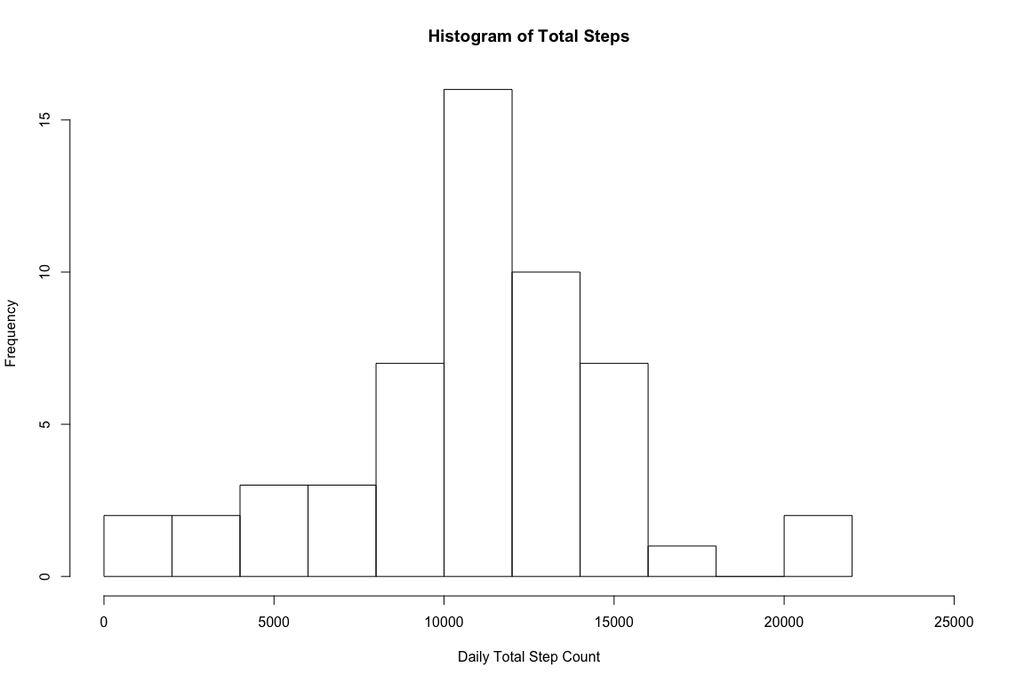

```r
hist(steptotals, breaks=10, xlim=c(0,25000), xlab="Daily Total Step Count",
     main="Histogram of Total Steps")
```

Now we can calulate the mean and median step counts.

```r
stepmean <- mean(steptotals)
stepmedian <- median(steptotals)
```

## What is the average daily activity pattern?

Make a time series plot (i.e. type = “l”) of the 5-minute interval (x-axis) and the average number of steps taken, averaged across all days (y-axis)

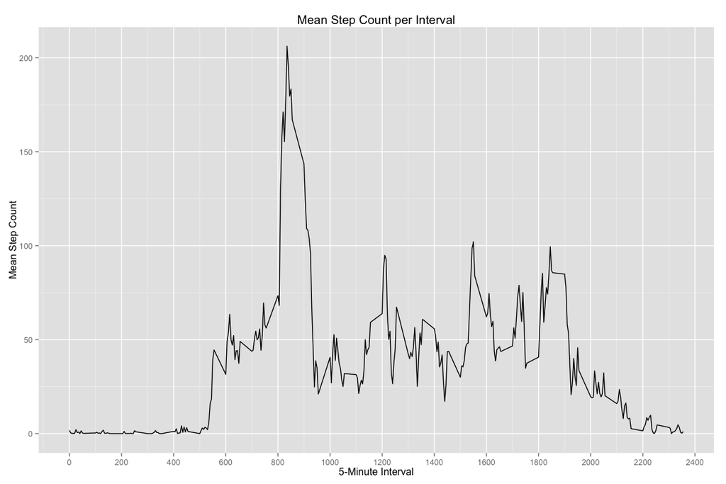

```r
intervals <- wsteps[1]
stepMean <- transmute(wsteps, intSteps=rowMeans(wsteps[-1], na.rm=TRUE))
intStepMean <- cbind(intervals, stepMean)
#The Plot
ggplot(intStepMean, aes(x=interval, y=intSteps)) + geom_line() + ggtitle("Mean Step Count per Interval") + scale_x_continuous(breaks=(seq(0,2500, by=200))) + xlab("5-Minute Interval") + ylab("Mean Step Count")
```

Which 5-minute interval, on average across all the days in the dataset, contains the maximum number of steps?

```r
maxInt <- filter(intStepMean, intSteps==max(intSteps))
```

The interval 835 contains the maximum average number of steps; 206.1698113.

## Imputing missing values

First we will calculate and report the total number of missing values in the dataset (i.e. the total number of rows with NAs)

```r
# For this we use the 'long' form of the data
naRows <- count(filter(steps, is.na(steps$steps)))
```

The number of missing intervals in the dataset is 2304.

Next we devise a strategy for filling in all of the missing values in the dataset:

```r
#The median interval value is assigned for NA values.
stepsImpute <- csteps %>%
  group_by(interval) %>%
  mutate(steps= replace(steps, is.na(steps), median(steps, na.rm=TRUE)))
```

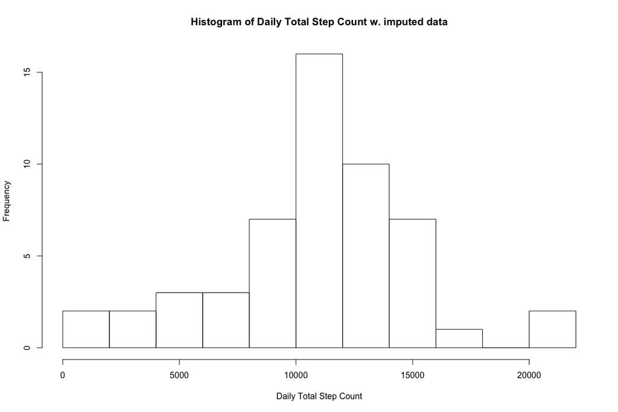

```r
histTotals <- stepsImpute %>%
  group_by(date) %>%
  transmute(steps= sum(steps))
# remove duplicate rows:
histTotals <- histTotals[!duplicated(histTotals),]
# The plot
hist(histTotals$steps, breaks=10, xlab="Daily Total Step Count",
     main="Histogram of Daily Total Step Count w. imputed data")
```

```r
# reporting
impStepMean <- mean(histTotals$steps)
impStepMedian <- median(histTotals$steps)
```

## Are there differences in activity patterns between weekdays and weekends?

First we create a new factor variable in the dataset with two levels – “weekday” and “weekend” indicating whether a given date is a weekday or weekend day.

```r
# convert date into 'date' format.
stepsImpute$date <- as.Date(stepsImpute$date)
# create weekday factor
weekDat <- stepsImpute %>%
  mutate(weekday= factor((weekdays(date)) %in% c('Saturday', 'Sunday')+1L, levels=1:2, labels=c('weekday', 'weekend')))
```

Then we create a panel plot containing a time series plot (i.e. type = “l”) of the 5-minute interval (x-axis) and the average number of steps taken, averaged across all weekday days or weekend days (y-axis).

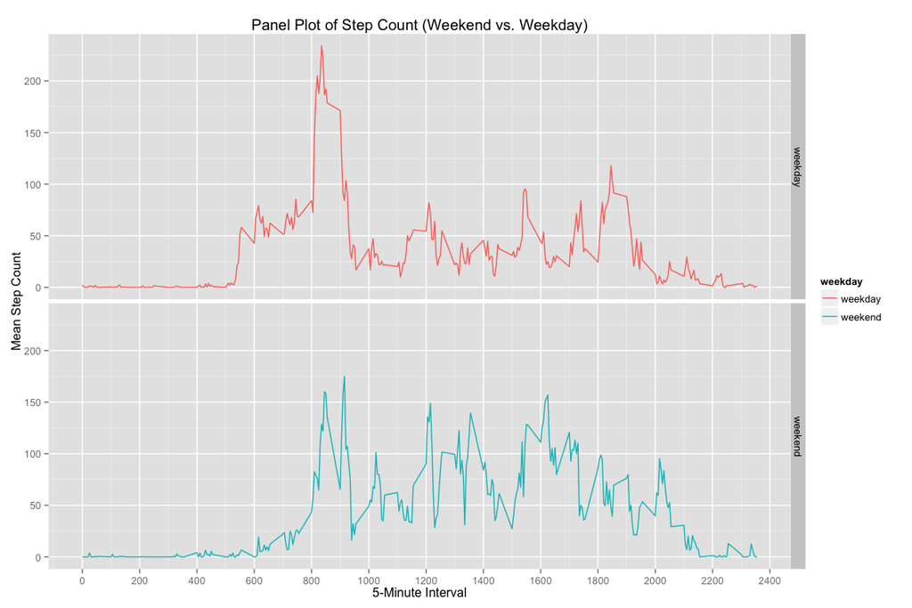

```r
weekDat1 <- weekDat %>%
  group_by(interval, weekday) %>%
  transmute(steps= mean(steps))
#remove duplicates
weekDat1 <- weekDat1[!duplicated(weekDat1),]
#The Plot
ggplot(weekDat1, aes(x=interval, y=steps, colour=weekday)) + geom_line() +
  ggtitle("Panel Plot of Step Count (Weekend vs. Weekday)") + scale_x_continuous(breaks=(seq(0,2500, by=200))) + xlab("5-Minute Interval") + ylab("Mean Step Count") + facet_grid(weekday~.)
```

As can be seen from the panel plot, the individual has a higher level of activity on weekday mornings than weekend mornings, though they have a higher overall level of activity during a weekend day.